# Praca domowa 2

Jagna Jażdżyk

## Dane

Dane wykorzystane w Pracy domowej 2 dotyczą wyników egzaminów z 3 umiejętności: czytania, pisania i operacji matematycznych. Dodatkowo dostępne są podstawowe informacje o studentach i ich rodzicach. Opis wszystkich kolumn znajduje się również w pliku `README.md`.

| Zmienna | Opis |
| --- | --- |
| **gender** | płeć |
| **race.ethnicity** | pochodzenie etniczne |
| **parental.level.of.education** | wykształcenie rodziców |
| **lunch** | jaki obiad jedli uczniowie w dniu egzaminu |
| **test.preparation.course** | czy uczeń odbył kurs przygotowujący |
| **math.score** | wynik egzaminu z matematyki |
| **reading.score** | wynik egzaminu z czytania |
| **writing.score** | wynik egzaminu z pisania |

## Zadanie 1

Jak wyglądają rozkłady wyników uczniów z trzech przedmiotów (matematyka, czytanie, pisanie)?

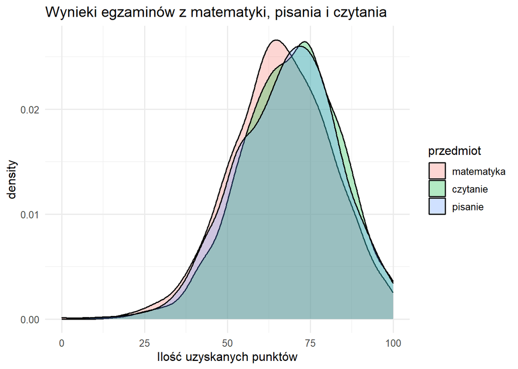

```r
zd1<-df %>%
  pivot_longer(cols = ends_with("score"),
               names_to = "subject",
               values_to = "score")

View(zd1)
plot<-ggplot(zd1,aes(x = race.ethnicity, y = score, fill = subject)) +
  geom_boxplot(alpha = 0.8)+
  labs(title = "Wynieki egzaminów z matematyki, pisania i czytania",
       x ="Grupy etniczne",
       y = "Ilość uzyskanych punktów",
       fill = "przedmiot")+
  theme_minimal(base_size = 13) +
  scale_fill_discrete(labels = c("matematyka","czytanie","pisanie"))+
  theme(plot.title = element_text(hjust = 0.4),
        axis.title.x = element_text(size = 11, vjust = -2),
        axis.title.y = element_text(size = 11))

plot2<-plot<-ggplot(zd1,aes( y = score, fill = subject))+
    geom_density(alpha = 0.3)+
  coord_flip()+
    labs(title = "Wynieki egzaminów z matematyki, pisania i czytania",
       y = "Ilość uzyskanych punktów",
       fill = "przedmiot")+
    scale_fill_discrete(labels = c("matematyka","czytanie","pisanie"))+
  theme(plot.title = element_text(hjust = 0.4),
        axis.title.y = element_text(size = 11))+
        theme_minimal(base_size = 12)
plot2
```

**Komentarz:** Rozkłady wyników z każdego z przedmiotów są zbliżone do rozkładu normalnego. Wyniki z czytania i pisania są bardzo podobne, natomiast rozkład wyników z matematyki jest nieco przesunięty w lewo -> uczniowie osiągają w tym przedmiocie nieco gorsze wyniki.

## Zadanie 2

Czy istnieje zauważalna różnica w wynikach między uczniami i uczennicami?

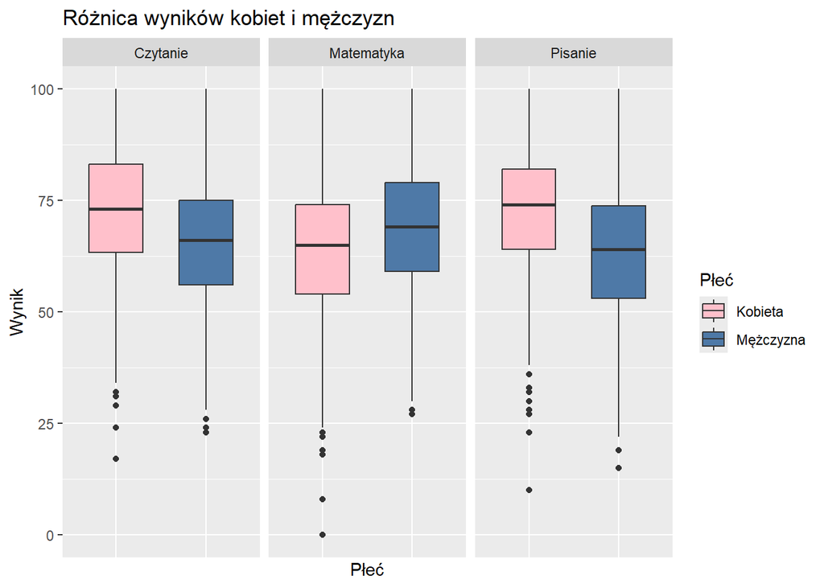

```r
zd2<-zd1 %>%
  group_by(gender, subject) %>%
    mutate(subject = recode(subject,
                          "math.score" = "Matematyka",
                          "reading.score" = "Czytanie",
                          "writing.score" = "Pisanie"),
         gender = recode(gender,
                         "female" = "Kobieta",
                         "male" = "Mężczyzna"))


zd2_plot<- ggplot(zd2, aes(x = gender, y = score, fill = gender)) +
  geom_boxplot(width = 0.6) +
  facet_wrap(~subject, nrow = 1)+
  labs(title = "Różnica wyników kobiet i mężczyzn",
       x = "Płeć",
       y = "Wynik",
       fill = "Płeć") +
  scale_fill_manual(values = c("Kobieta" = "pink", "Mężczyzna" = "#4E79A7"))+
  scale_x_discrete(labels = NULL)+
  theme(axis.ticks.x = element_blank())



zd2_plot
```

**Komentarz:** Mężczyźni są lepsi z matematyki, z dwóch innych egzaminów lepsze wyniki mają kobiety. Większe różnice są między wynikami kobiet i mężczyzn z czytania i pisania.

## Zadanie 3

Czy uczniowie, którzy ukończyli kurs przygotowawczy, osiągają lepsze wyniki niż pozostali?

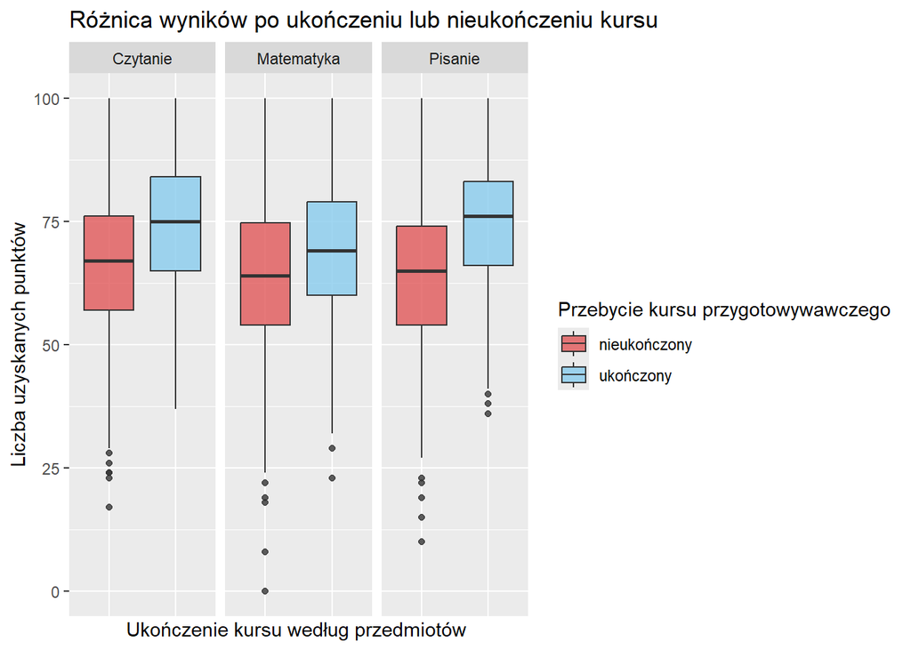

```r
zd3<-zd1 %>%
  mutate(subject = recode(subject,
                          "math.score" = "Matematyka",
                          "reading.score" = "Czytanie",
                          "writing.score" = "Pisanie"),
         test.preparation.course = recode(test.preparation.course,
                                          "completed" = "ukończony",
                                          "none" = "nieukończony"))


zd3_plot<-ggplot(zd3, aes(x = test.preparation.course, y = score, fill = test.preparation.course))+
  geom_boxplot(alpha = 0.8)+
  facet_grid(~subject)+
  labs(title = "Różnica wyników po ukończeniu lub nieukończeniu kursu",
       x = "Ukończenie kursu według przedmiotów ",
       y = " Liczba uzyskanych punktów ",
       fill = "Przebycie kursu przygotowywawczego")+
  scale_x_discrete(labels = NULL)+
  theme(axis.ticks.x = element_blank())+
  scale_fill_manual(values = c("nieukończony" = "#E15759", "ukończony" = "#88CCEE"))

zd3_plot
```

**Komentarz:** Wykres przedstawia wyniki z egzaminów dla uczniów z różnych przedmiotów, rozdzielone według statusu ukończenia kursu przygotowawczego. Widać, że uczniowie, którzy ukończyli kurs, osiągają lepsze wyniki niż ci, którzy go nie ukończyli.

## Zadanie 4

Jaki jest związek między poziomem wykształcenia rodziców a średnimi wynikami uczniów?

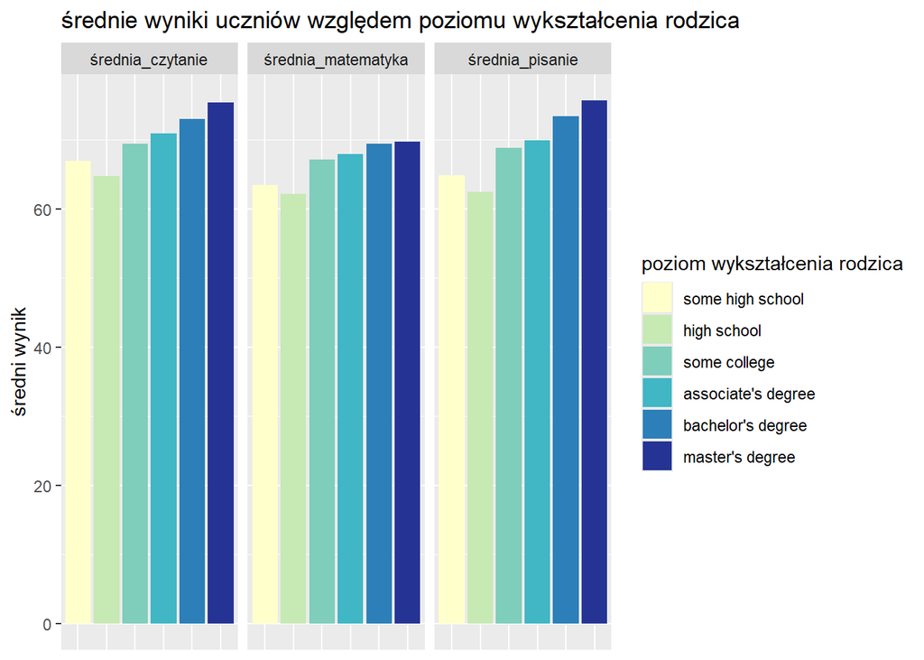

```r
library(tidyr)
df$parental.level.of.education <- factor(df$parental.level.of.education,
  levels = c("some high school", "high school", "some college",
             "associate's degree", "bachelor's degree", "master's degree"))
zd4<- df %>%
  group_by(parental.level.of.education) %>%
  summarise(średnia_matematyka = mean(math.score),
            średnia_pisanie = mean(writing.score),
            średnia_czytanie = mean(reading.score)) %>%
    pivot_longer(cols = starts_with("średnia"),
               names_to = "średnia_z_przedmiotu",
               values_to = "ilość_punktów") %>%
  ggplot(aes(x = parental.level.of.education, y = ilość_punktów, fill = parental.level.of.education))+
  geom_col()+
    facet_wrap(~średnia_z_przedmiotu,nrow = 1)+

  labs(title = "średnie wyniki uczniów względem poziomu wykształcenia rodzica",
         y = "średni wynik",
         x = NULL,
         fill = "poziom wykształcenia rodzica")+
  scale_x_discrete(labels = NULL)+
  scale_fill_brewer(palette = "YlGnBu")+
  theme(axis.ticks.x = element_blank())

zd4
```

**Komentarz:** Wpierw ustawiam wykształcenie od najmniejszego do najwiekszego aby dane na wykresie były bardziej intuicyjne i czytelne. Robię średnie z wyników uczniów względem wykształcenia rodzica i robię na tej podstawie wykres. W większości przypadków wykształcenie rodzica jest proporcjonalne do wyników egzaminów dzieci – wyższe wykształcenie wiąże się z lepszymi wynikami. Wyjątek stanowią kolumny „some high school” i „high school”, gdzie wyniki są odwrotne do tych których byśmy oczekiwali: dzieci rodziców z wykształceniem „some high school” osiągają lepsze wyniki niż dzieci rodziców z wykształceniem „high school”.

## Zadanie 5

Czy płeć i wykształcenie rodzica wpływa na wynik z matematyki?

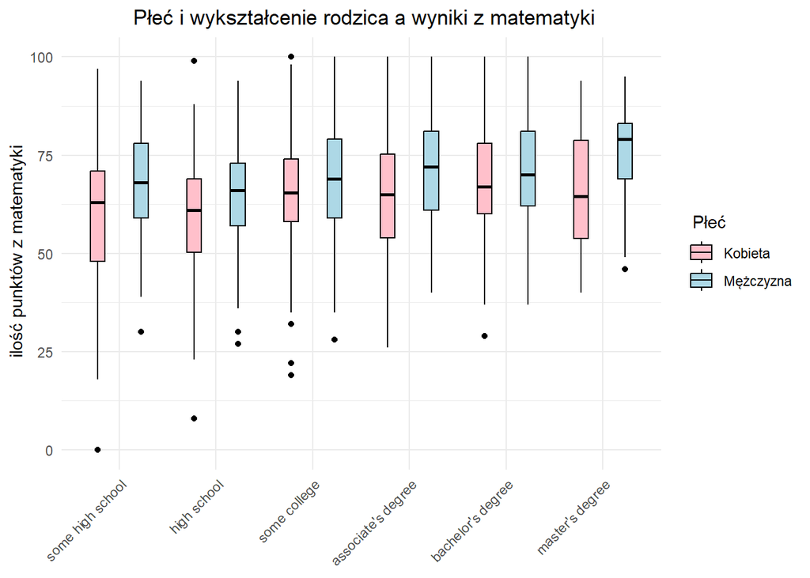

```r
zd5<-df %>%
  mutate(gender = recode (gender, "female" = "Kobieta",
                          "male" = "Mężczyzna")) %>%
  ggplot(aes(x = parental.level.of.education, y = math.score, fill = gender))+
  geom_boxplot(width = 0.3, position = position_dodge(0.9), color = "black")+
  scale_fill_manual(values = c("Kobieta" = "pink", "Mężczyzna" = "lightblue"))+
    theme_minimal() +
  theme(axis.text.x = element_text(angle = 45, hjust = 1),
         plot.title = element_text(hjust = 0.5))+
  labs( title = " Płeć i wykształcenie rodzica a wyniki z matematyki",
        y = " ilość punktów z matematyki",
        x = NULL,
        fill = " Płeć")

zd5
```

**Komentarz:** Z wykresu wynika, że mężczyżni mają lepsze wyniki od kobiet. Njlepsze wyniki mają meżczyźni, których rodzice mają wykształcenie “master’s degree”. Najgorsze wyniki tutaj zarówno u kobiet jak i meżczyzn są dla osób, których rodzce mają wykształcenie “high school”.

## Zadanie 6

Czy istnieje zależność między wynikami z matematyki a wynikami z czytania lub pisania?

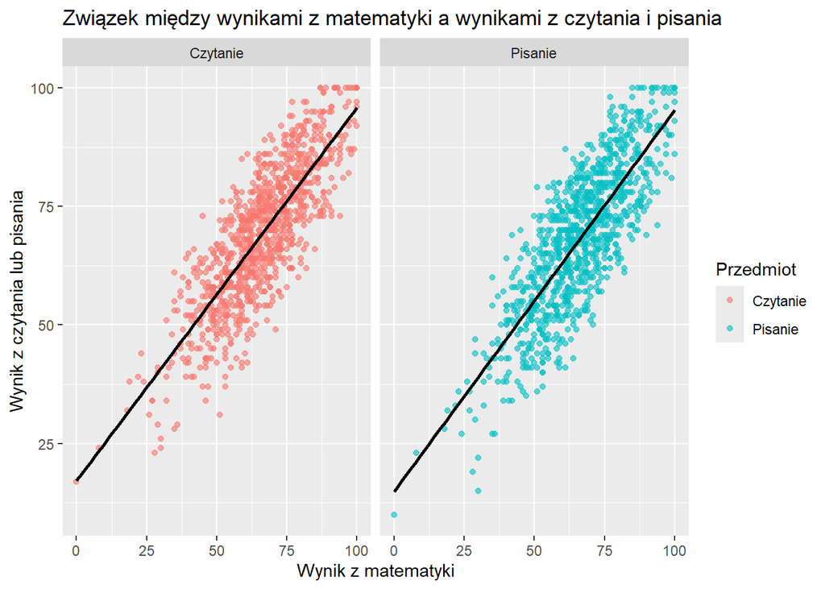

```r
zd6 <- df %>%
  pivot_longer(cols = c(reading.score,writing.score),
               names_to = "czytanie_pisanie",
               values_to = "score"
               ) %>%
  mutate(czytanie_pisanie = recode(czytanie_pisanie,
                                   "reading.score" = "Czytanie",
                                   "writing.score" = "Pisanie")) %>%
  ggplot(aes( x = math.score, y = score, color = czytanie_pisanie))+
  geom_point(alpha = 0.6)+
  geom_smooth(method = "lm", se = FALSE, color = "black")+
  facet_wrap(~czytanie_pisanie, nrow = 1)+
    labs(
    title = "Związek między wynikami z matematyki a wynikami z czytania i pisania",
    x = "Wynik z matematyki",
    y = "Wynik z czytania lub pisania",
    color = "Przedmiot"
  )


zd6
```

**Komentarz:** Widać zależność, w większości przypadków tam, gdzie uczeń miał dobry wynik z matematyki miał też dobry wynik z pisania i czytania. Zależności dla pisania i czytania sa bardzo podobne.